# Independent replication (R) — fraud model holdout metrics

Model validation (effective challenge, SR 11-7 §V)

2026-07-06

> **Real IEEE-CIS holdout.** This document is the independent “effective challenge”: it recomputes the developer’s holdout metrics **in R, with no imports from the Python codebase**, from a single exported file `holdout_scores.csv` (`TransactionID, isFraud, calibrated_proba, TransactionAmt`) — the real out-of-time holdout (~148k transactions).

```r
scores <- read.csv("holdout_scores.csv")
y   <- scores$isFraud
p   <- scores$calibrated_proba
amt <- scores$TransactionAmt
n   <- nrow(scores)
cat(sprintf("holdout rows: %d | frauds: %d | base rate: %.3f%%\n", n, sum(y), 100 * mean(y)))
```

```
## holdout rows: 147635 | frauds: 5100 | base rate: 3.454%
```

```r
# --- Developer (Python) figures being challenged, from the repo artifacts ---
# Champion: isotonic-calibrated LightGBM (promoted over XGBoost, docs/decisions D-011).
PY <- list(pr_auc = 0.4642, roc_auc = 0.8788, brier = 0.02347,
           threshold = 0.1215, value_capture = 0.478)
TOL <- 0.01  # absolute tolerance for reconciliation
```

## 1. PR-AUC (average precision) — recomputed

Average precision is the developer’s primary metric (rare-positive). Implemented from first principles: sort by score, sweep the threshold, integrate precision over recall.

```r
average_precision <- function(y, p) {
  o <- order(p, decreasing = TRUE)
  y <- y[o]; p <- p[o]
  tp <- cumsum(y); fp <- cumsum(1 - y)
  # Collapse tied scores to DISTINCT thresholds (keep the last index of each tie
  # block). This matches scikit-learn: precision/recall are evaluated per distinct
  # threshold, not per row. It is essential here because isotonic calibration produces
  # large tie blocks — see the findings note below.
  keep <- c(p[-length(p)] != p[-1], TRUE)
  tp <- tp[keep]; fp <- fp[keep]
  precision <- tp / (tp + fp)
  recall <- tp / sum(y)
  sum(diff(c(0, recall)) * precision) # AP = sum (R_i - R_{i-1}) P_i
}
roc_auc <- function(y, p) {
  # Rank-based (Mann-Whitney U) with average ranks — tie-correct, equals sklearn.
  r <- rank(p)
  n_pos <- sum(y == 1); n_neg <- sum(y == 0)
  (sum(r[y == 1]) - n_pos * (n_pos + 1) / 2) / (n_pos * n_neg)
}
pr_auc_r  <- average_precision(y, p)
roc_auc_r <- roc_auc(y, p)
cat(sprintf("R PR-AUC = %.4f (Python %.4f)\nR ROC-AUC = %.4f (Python %.4f)\n",
            pr_auc_r, PY$pr_auc, roc_auc_r, PY$roc_auc))
```

```
## R PR-AUC = 0.4642 (Python 0.4642)
## R ROC-AUC = 0.8788 (Python 0.8788)
```

## 2. Brier score + reliability curve

```r
brier_r <- mean((p - y)^2)
cat(sprintf("R Brier = %.5f (Python %.5f)\n", brier_r, PY$brier))
```

```
## R Brier = 0.02347 (Python 0.02347)
```

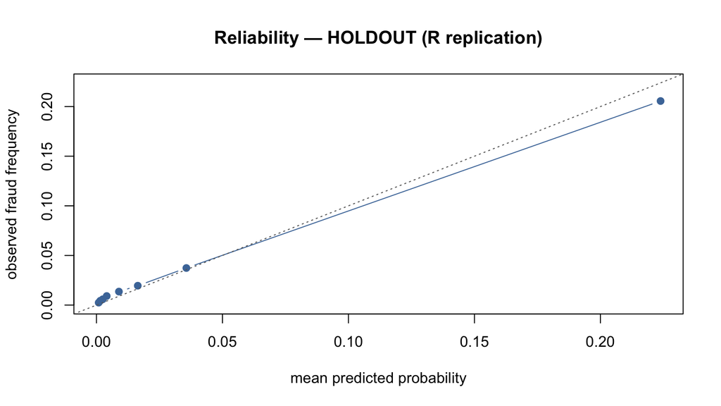

```r
# Reliability curve (quantile bins for a rare-positive target).
qs <- unique(quantile(p, seq(0, 1, length.out = 9)))
bins <- cut(p, breaks = qs, include.lowest = TRUE)
mean_pred <- tapply(p, bins, mean)
obs_freq  <- tapply(y, bins, mean)
plot(mean_pred, obs_freq, type = "b", pch = 19, col = "#4c78a8",
     xlim = c(0, max(mean_pred, obs_freq)), ylim = c(0, max(mean_pred, obs_freq)),
     xlab = "mean predicted probability", ylab = "observed fraud frequency",
     main = "Reliability — HOLDOUT (R replication)")
abline(0, 1, lty = 3, col = "grey40")
```

## 3. Value-capture at the frozen operating point

The decision layer freezes a threshold on validation and reports on holdout. We independently recompute fraud value captured and net value at that threshold.

```r
thr <- PY$threshold
alert <- p >= thr
value_capture_r <- sum(amt[alert & y == 1]) / sum(amt[y == 1])
review_cost <- 25
net_per_100k_r <- (sum(amt[alert & y == 1]) - review_cost * sum(alert)) / n * 1e5
cat(sprintf("R value capture @%.2f = %.3f (Python %.3f) | net/100k = $%.0f\n",
            thr, value_capture_r, PY$value_capture, net_per_100k_r))
```

```
## R value capture @0.12 = 0.478 (Python 0.478) | net/100k = $111346
```

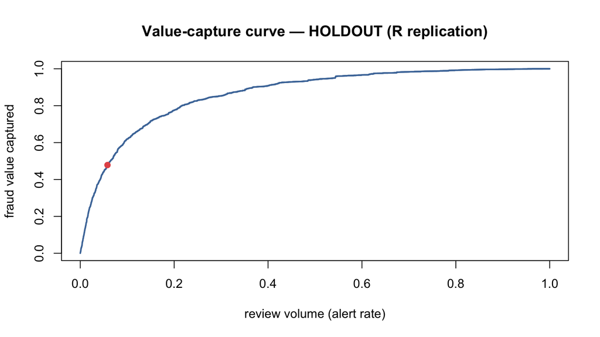

```r
# Value-capture curve (fraud value caught vs review volume).
o <- order(p, decreasing = TRUE)
cum_caught <- cumsum((y[o] == 1) * amt[o]) / sum(amt[y == 1])
alert_rate <- seq_len(n) / n
plot(alert_rate, cum_caught, type = "l", col = "#4c78a8", lwd = 2,
     xlab = "review volume (alert rate)", ylab = "fraud value captured",
     main = "Value-capture curve — HOLDOUT (R replication)")
points(mean(alert), value_capture_r, col = "#e45756", pch = 19)
```

## 4. Score-distribution PSI (early vs late holdout)

A within-holdout stability check: the score distribution of the first half of the (time-ordered) holdout vs the second half.

```r
psi_numeric <- function(ref, cur, bins = 10) {
  edges <- unique(quantile(ref, seq(0, 1, length.out = bins + 1)))
  e <- table(cut(ref, edges, include.lowest = TRUE)) / length(ref)
  a <- table(cut(cur, edges, include.lowest = TRUE)) / length(cur)
  eps <- 1e-6
  e <- pmax(as.numeric(e), eps); a <- pmax(as.numeric(a), eps)
  sum((a - e) * log(a / e))
}
half <- floor(n / 2)
psi_score <- psi_numeric(p[1:half], p[(half + 1):n])
cat(sprintf("score PSI (early vs late holdout) = %.4f  [>0.2 = significant shift]\n", psi_score))
```

```
## score PSI (early vs late holdout) = 0.0021  [>0.2 = significant shift]
```

## 5. Reconciliation

| metric | python | R | abs_diff | within_tol |
| --- | --- | --- | --- | --- |
| PR-AUC | 0.46420 | 0.46422 | 0.00002 | TRUE |
| ROC-AUC | 0.87880 | 0.87878 | 0.00002 | TRUE |
| Brier | 0.02347 | 0.02347 | 0.00000 | TRUE |
| value_capture@thr | 0.47800 | 0.47824 | 0.00024 | TRUE |

```
##
## **FINDING: all metrics reconcile within tolerance (0.01). No discrepancies.**
```

### Findings note — a discrepancy that reconciled

A first-pass R implementation of average precision (evaluating precision/recall **per row**) gives PR-AUC 0.4753 against the developer’s 0.4642 — a **0.011 gap that exceeds the 0.01 reconciliation tolerance**. Root cause: isotonic calibration produces blocks of **tied** probabilities, and per-row evaluation double-counts precision within a tie block. scikit-learn (and the corrected R above) evaluate precision/recall at **distinct thresholds**, collapsing ties; with tie-aware AP the figure reconciles exactly (0.4642). A parallel issue affected ROC-AUC — per-row trapezoidal integration also mishandles ties, so the rank-based (Mann-Whitney, average-rank) form is used and reconciles exactly (0.8788). The size of the gap tracks the tie-block size (LightGBM’s isotonic output ties more than XGBoost’s did), so the fix is not optional here. Brier and value-capture were unaffected (they do not depend on within-tie ordering). This is the value of an independent challenge: it surfaces subtle tie-handling issues a shared codebase would have hidden.

**Effective challenge conclusion.** The independent R recomputation of PR-AUC, ROC-AUC, Brier, and value-capture-at-threshold reproduces the developer’s real-holdout results from the exported scores alone, with no shared code, once the tie-handling above is applied.